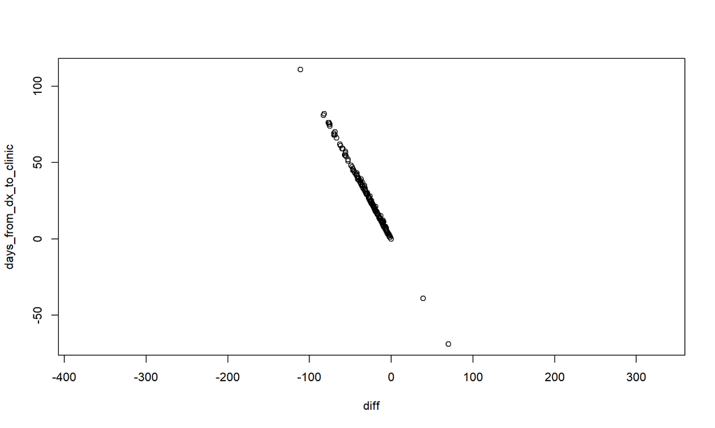

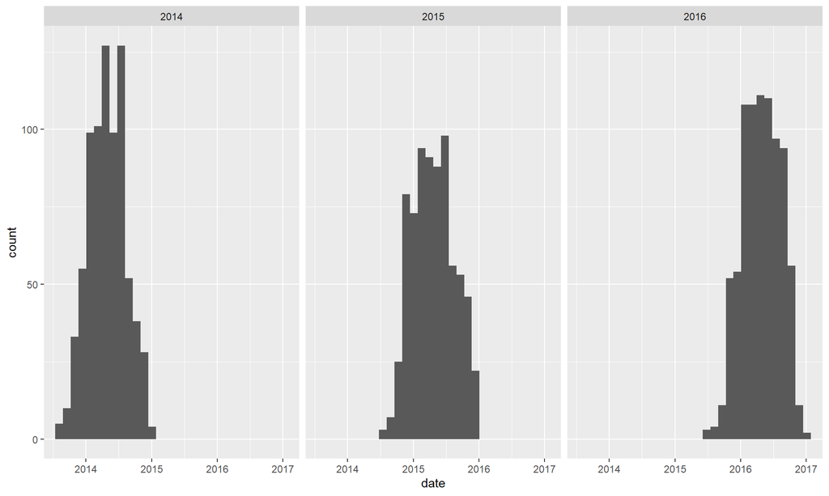

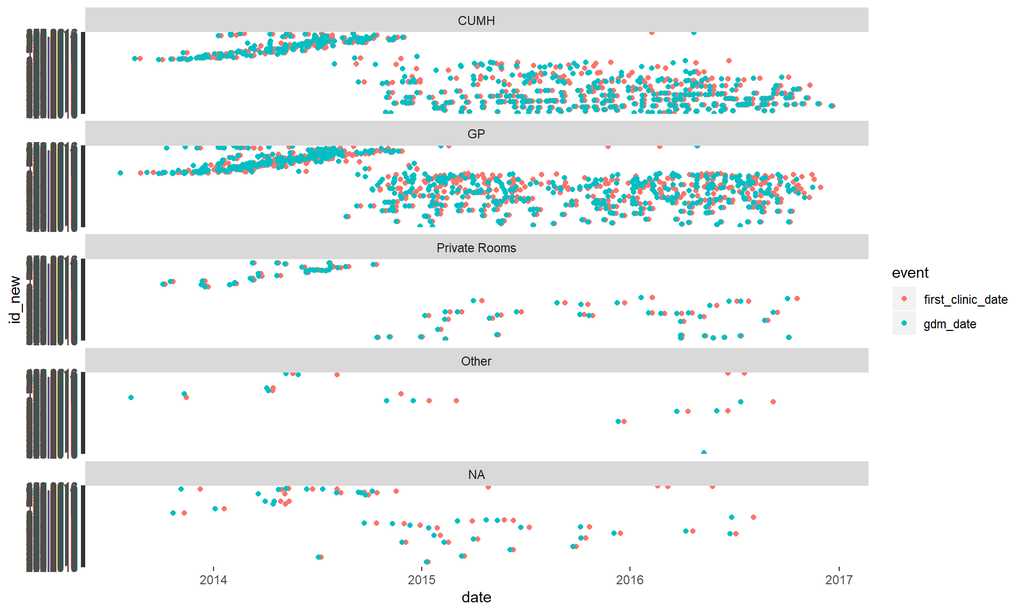

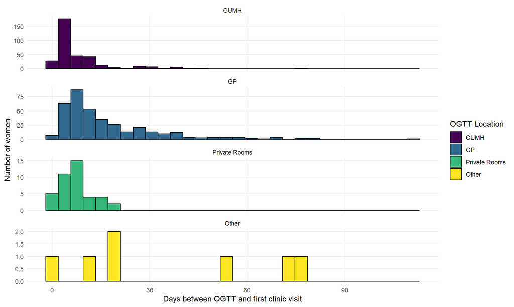

Fitting linear model: del_gstdays ~ days_from_dx_to_clinic + gtt_location

|  | Estimate | Std. Error | t value | Pr(>\|t\|) |
| --- | --- | --- | --- | --- |
| **(Intercept)** | 269.6 | 0.5799 | 465 | 0 |
| **days_from_dx_to_clinic** | 0.05395 | 0.02665 | 2.024 | 0.04332 |
| **gtt_locationGP** | -0.1975 | 0.7985 | -0.2473 | 0.8047 |
| **gtt_locationPrivate Rooms** | -2.335 | 1.648 | -1.417 | 0.1569 |
| **gtt_locationOther** | -5.979 | 3.878 | -1.542 | 0.1235 |

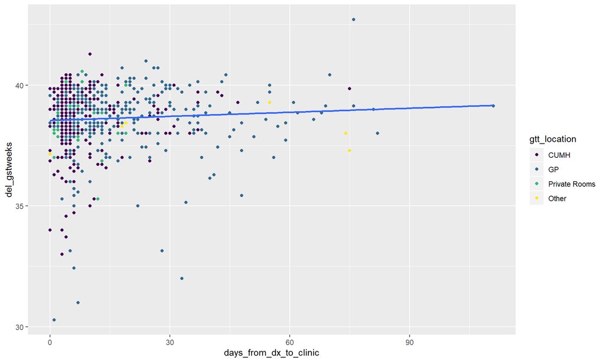

# Growth

| Variable | N | Mean ± SD or N(%) | Med [IQR] | (Min, Max) |
| --- | --- | --- | --- | --- |
| sex | 617 |  |  |  |
| Male |  | 317 (51.4%) | 317 (51.4%) |  |
| Female |  | 300 (48.6%) | 300 (48.6%) |  |
| del_gstweeks | 1172 | 38.6 ± 1.4 | 38.9 [38, 39.3] | (27.1, 42.7) |
| birth_weight_1 | 1180 | 3450.9 ± 538.5 | 3460 [3140, 3800] | (940, 5700) |
| grow | 1017 | 3312.2 ± 305.9 | 3360.9 [3197.2, 3499.7] | (1040.1, 3987.2) |
| grow_centile | 1016 | 59.1 ± 30.4 | 63.9 [33.8, 87] | (0, 100) |
| igb_wt_centile | 616 | 70.5 ± 26.8 | 78.3 [51.6, 93.8] | (1.7, 100) |
| macrosomic_4 | 1180 |  |  |  |
| No |  | 1015 (86%) | 1015 (86%) |  |
| Yes |  | 165 (14%) | 165 (14%) |  |
| macrosomic_4.5 | 1180 |  |  |  |
| No |  | 1155 (97.9%) | 1155 (97.9%) |  |
| Yes |  | 25 (2.1%) | 25 (2.1%) |  |
| grow_size_ga | 1016 |  |  |  |
| LGA |  | 210 (20.7%) | 210 (20.7%) |  |
| Normal |  | 736 (72.4%) | 736 (72.4%) |  |
| SGA |  | 70 (6.9%) | 70 (6.9%) |  |
| igb_size_ga | 616 |  |  |  |
| LGA |  | 204 (33.1%) | 204 (33.1%) |  |
| Normal |  | 396 (64.3%) | 396 (64.3%) |  |
| SGA |  | 16 (2.6%) | 16 (2.6%) |  |
| age | 1173 | 33.1 ± 4.9 | 33 [30, 36] | (15, 49) |
| irish_eth | 1040 |  |  |  |
| Irish |  | 714 (68.7%) | 714 (68.7%) |  |
| Not Irish |  | 326 (31.3%) | 326 (31.3%) |  |
| risky_eth | 1040 |  |  |  |
| No |  | 952 (91.5%) | 952 (91.5%) |  |
| Yes |  | 88 (8.5%) | 88 (8.5%) |  |
| parity | 1181 | 1.2 ± 1.3 | 1 [0, 2] | (0, 13) |
| height | 1171 | 1.6 ± 0.1 | 1.6 [1.6, 1.7] | (1.4, 1.9) |
| weight | 1171 | 82.4 ± 20.4 | 79.5 [67, 94.5] | (42.2, 174.7) |
| bmi | 1164 | 31 ± 7.1 | 30.1 [25.7, 35.1] | (15.6, 64.8) |
| bmi_class | 1164 |  |  |  |
| Underweight |  | 6 (0.5%) | 6 (0.5%) |  |
| Normal |  | 244 (21%) | 244 (21%) |  |
| Overweight |  | 318 (27.3%) | 318 (27.3%) |  |
| Obese |  | 468 (40.2%) | 468 (40.2%) |  |
| Very obese |  | 128 (11%) | 128 (11%) |  |

## GROW

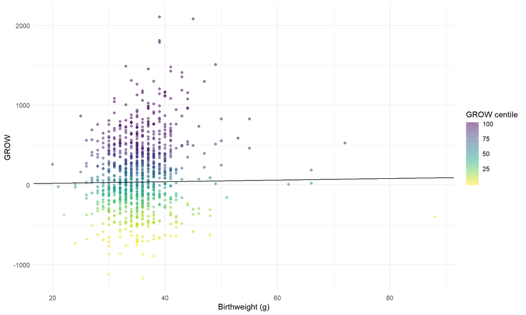

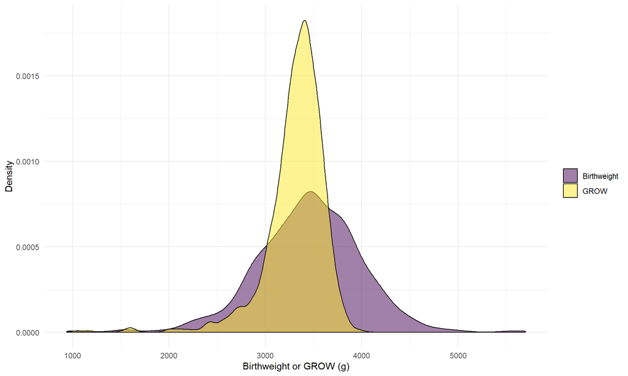

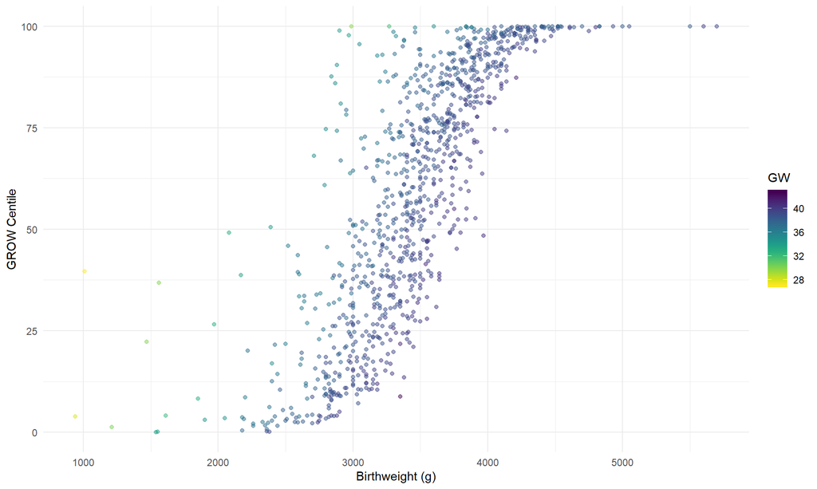

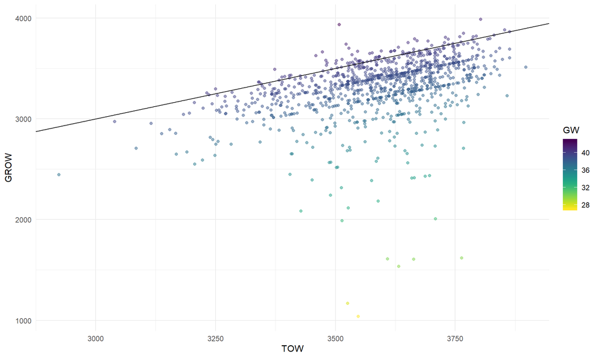

## Intergrowth

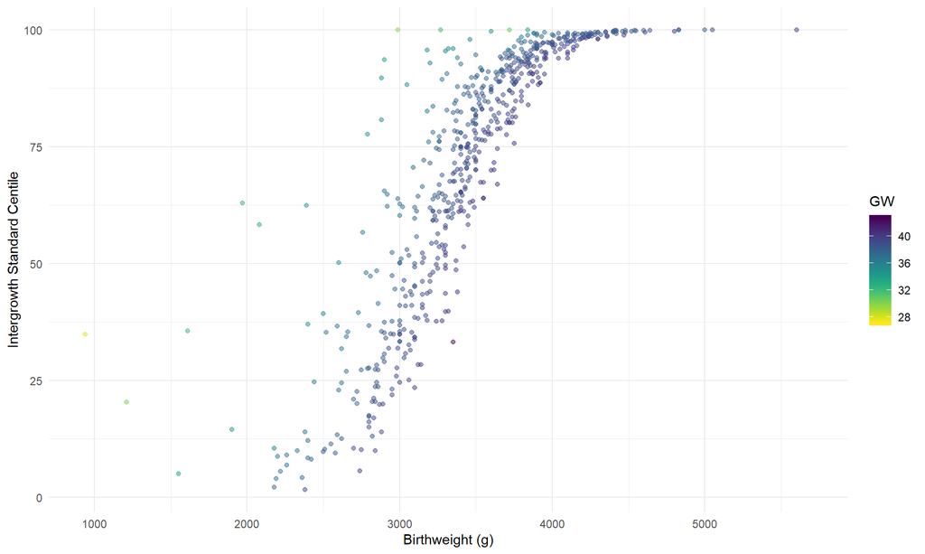

## Intergrowth vs GROW

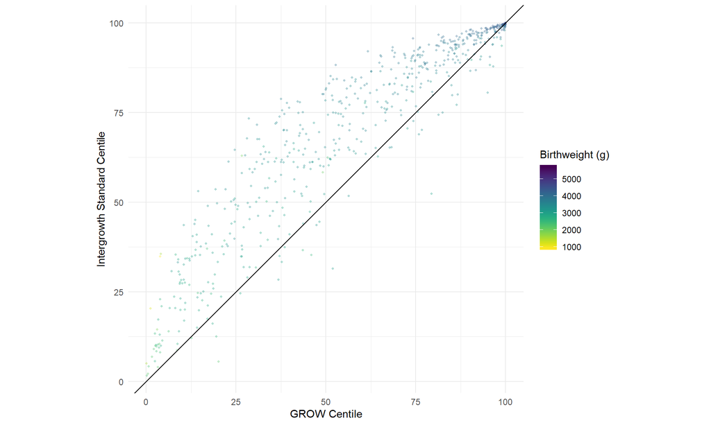

Objective: We aimed to describe the weights of singleton live births born to a cohort of women with Gestational Diabetes Mellitus (GDM) and identify predictors of larger than optimal growth.

Method: We analyzed data from 1181 women attending the Diabetes in Pregnancy Clinic between the years of 2014-2016. We calcuated customised weight centiles using the GROW method for 1016 of the infants at birth.

Results: The distribution of GROW centiles was notably skewed towards higher values (mean±SD = 59.1 ± 30.4; median[IQR] = 63.9 [33.8, 87]. While 14% and 2.1% for the infants had a birthweight greater than 4 or 4.5 kg, repspectively, 20.7% had a GROW centile >= 90. The birth weight of a mother’s previous infant, HBA1C and +2 hour fasting glucose at screening were strong predictors of larger than optimal (GROW) birth weight. There was a crude association between metformin use and lower GROW centiles, but this was nullfied by adjustment for key case-mix variables measured around the time of screening.

Conclusions: LGA infants, based on having a GROW centile >= 90, were common in this cohort. We obserfved no strong associations between treatment options and infant GROW centile.

# Predictors

Fitting linear model: grow_diff ~ gtt_location

|  | Estimate | Std. Error | t value | Pr(>\|t\|) |
| --- | --- | --- | --- | --- |
| **(Intercept)** | 143.2 | 21.68 | 6.607 | 6.454e-11 |
| **gtt_locationGP** | -4.448 | 29.53 | -0.1506 | 0.8803 |
| **gtt_locationPrivate Rooms** | 66.74 | 60.13 | 1.11 | 0.2674 |
| **gtt_locationOther** | 22.51 | 129.3 | 0.1741 | 0.8618 |

Fitting linear model: grow_diff ~ gtt_gstweeks

|  | Estimate | Std. Error | t value | Pr(>\|t\|) |
| --- | --- | --- | --- | --- |
| **(Intercept)** | 145.2 | 63.91 | 2.272 | 0.02328 |
| **gtt_gstweeks** | 0.0007774 | 2.237 | 0.0003476 | 0.9997 |

Fitting linear model: grow_diff ~ bmi

|  | Estimate | Std. Error | t value | Pr(>\|t\|) |
| --- | --- | --- | --- | --- |
| **(Intercept)** | 26.7 | 62.1 | 0.43 | 0.6673 |
| **bmi** | 3.864 | 1.957 | 1.974 | 0.04863 |

Fitting linear model: grow_diff ~ age

|  | Estimate | Std. Error | t value | Pr(>\|t\|) |
| --- | --- | --- | --- | --- |
| **(Intercept)** | 65.29 | 95.45 | 0.684 | 0.4941 |
| **age** | 2.44 | 2.848 | 0.8566 | 0.3918 |

Fitting linear model: grow_diff ~ no_of_previous_gdm_episodes

|  | Estimate | Std. Error | t value | Pr(>\|t\|) |
| --- | --- | --- | --- | --- |
| **(Intercept)** | 133.1 | 15.48 | 8.599 | 3.011e-17 |
| **no_of_previous_gdm_episodes1** | 70.09 | 36.63 | 1.913 | 0.05597 |
| **no_of_previous_gdm_episodes2+** | 40.63 | 83.24 | 0.4881 | 0.6256 |

Fitting linear model: grow_diff ~ risky_eth

|  | Estimate | Std. Error | t value | Pr(>\|t\|) |
| --- | --- | --- | --- | --- |
| **(Intercept)** | 145.2 | 14.46 | 10.04 | 1.105e-22 |
| **risky_ethYes** | 11.57 | 49.43 | 0.2341 | 0.815 |

Fitting linear model: grow_diff ~ weight_of_biggest_baby

|  | Estimate | Std. Error | t value | Pr(>\|t\|) |
| --- | --- | --- | --- | --- |
| **(Intercept)** | -590.4 | 93.83 | -6.292 | 5.6e-10 |
| **weight_of_biggest_baby** | 0.2094 | 0.02533 | 8.266 | 7.248e-16 |

Fitting linear model: grow_diff ~ hba1c_at_diagnosis

|  | Estimate | Std. Error | t value | Pr(>\|t\|) |
| --- | --- | --- | --- | --- |
| **(Intercept)** | -287.5 | 97.78 | -2.941 | 0.003353 |
| **hba1c_at_diagnosis** | 12.2 | 2.731 | 4.466 | 8.896e-06 |

Fitting linear model: grow_diff ~ fasting

|  | Estimate | Std. Error | t value | Pr(>\|t\|) |
| --- | --- | --- | --- | --- |
| **(Intercept)** | -2.74 | 104 | -0.02635 | 0.979 |
| **fasting** | 28.4 | 19.61 | 1.448 | 0.1479 |

Fitting linear model: grow_diff ~ x2hr_pp

|  | Estimate | Std. Error | t value | Pr(>\|t\|) |
| --- | --- | --- | --- | --- |
| **(Intercept)** | -43.08 | 52.5 | -0.8206 | 0.4121 |
| **x2hr_pp** | 25.82 | 6.899 | 3.743 | 0.0001922 |

Fitting linear model: grow_diff ~ diet_only

|  | Estimate | Std. Error | t value | Pr(>\|t\|) |
| --- | --- | --- | --- | --- |
| **(Intercept)** | 131.4 | 17.05 | 7.709 | 3.021e-14 |
| **diet_onlyNo** | 45.15 | 29.21 | 1.545 | 0.1226 |

Fitting linear model: grow_diff ~ metformin

|  | Estimate | Std. Error | t value | Pr(>\|t\|) |
| --- | --- | --- | --- | --- |
| **(Intercept)** | 198.2 | 29.28 | 6.769 | 2.199e-11 |
| **metforminNo** | -67.37 | 33.19 | -2.03 | 0.04261 |

Fitting linear model: grow_diff ~ basal_insulin

|  | Estimate | Std. Error | t value | Pr(>\|t\|) |
| --- | --- | --- | --- | --- |
| **(Intercept)** | 184.3 | 29.08 | 6.339 | 3.509e-10 |
| **basal_insulinNo** | -46.85 | 33.1 | -1.416 | 0.1572 |

Fitting linear model: grow_diff ~ prandial_insulin

|  | Estimate | Std. Error | t value | Pr(>\|t\|) |
| --- | --- | --- | --- | --- |
| **(Intercept)** | 207.1 | 60.16 | 3.443 | 0.0005997 |
| **prandial_insulinNo** | -66.36 | 61.9 | -1.072 | 0.284 |

Fitting linear model: grow_diff ~ metformin + bmi + no_of_previous_gdm_episodes + weight_of_biggest_baby + hba1c_at_diagnosis + x2hr_pp

|  | Estimate | Std. Error | t value | Pr(>\|t\|) |
| --- | --- | --- | --- | --- |
| **(Intercept)** | -1280 | 181.5 | -7.05 | 4.695e-12 |
| **metforminNo** | 2.466 | 39.2 | 0.06291 | 0.9499 |
| **bmi** | -0.4531 | 2.506 | -0.1808 | 0.8566 |
| **no_of_previous_gdm_episodes1** | 47.3 | 39.12 | 1.209 | 0.227 |
| **no_of_previous_gdm_episodes2+** | 1.567 | 84.03 | 0.01864 | 0.9851 |
| **weight_of_biggest_baby** | 0.2231 | 0.02638 | 8.459 | 1.879e-16 |
| **hba1c_at_diagnosis** | 13.78 | 3.435 | 4.013 | 6.721e-05 |
| **x2hr_pp** | 20.94 | 8.895 | 2.354 | 0.01886 |

Fitting linear model: grow_centile ~ metformin + bmi + no_of_previous_gdm_episodes + weight_of_biggest_baby + hba1c_at_diagnosis

|  | Estimate | Std. Error | t value | Pr(>\|t\|) |
| --- | --- | --- | --- | --- |
| **(Intercept)** | -15.99 | 11.93 | -1.34 | 0.1808 |
| **metforminNo** | -0.3616 | 2.677 | -0.1351 | 0.8926 |
| **bmi** | -0.07388 | 0.1679 | -0.44 | 0.6601 |
| **no_of_previous_gdm_episodes1** | 3.239 | 2.666 | 1.215 | 0.2248 |
| **no_of_previous_gdm_episodes2+** | 0.3398 | 5.68 | 0.05982 | 0.9523 |
| **weight_of_biggest_baby** | 0.01428 | 0.001796 | 7.949 | 8.382e-15 |
| **hba1c_at_diagnosis** | 0.7401 | 0.2244 | 3.298 | 0.001029 |

Fitting linear model: grow_centile ~ metformin

|  | Estimate | Std. Error | t value | Pr(>\|t\|) |
| --- | --- | --- | --- | --- |
| **(Intercept)** | 62.25 | 2.02 | 30.82 | 1.615e-147 |
| **metforminNo** | -4.104 | 2.289 | -1.793 | 0.0733 |

# GTT screening

This is a plot of fasting and 2-hour gluose values, for women with both measures. The yellow markers are women with 1-hour glucose >= 10 mmol. There are a few women who don’t seem to meet any of these criteria.

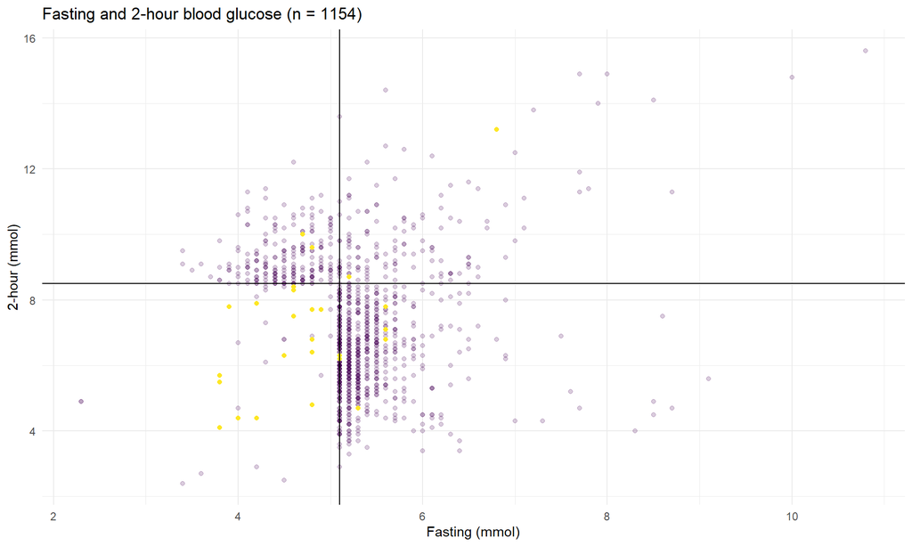

Note: Several women who fall under the criteria for both fasting and +2 hour glucose are also missing data for the + 1 hour value.

| Variable | N | N (%) |
| --- | --- | --- |
| gtt_criteria | 1145 |  |
| Met any criteria |  | 1145 (100%) |
| fasting_criteria | 1167 |  |
| No |  | 264 (22.6%) |
| Yes |  | 903 (77.4%) |
| onehour_criteria | 36 |  |
| No |  | 10 (27.8%) |
| Yes |  | 26 (72.2%) |
| towhour_criteria | 1155 |  |
| No |  | 777 (67.3%) |
| Yes |  | 378 (32.7%) |

## Timing of GTT

**Figure 1** Distribution of gestational ages when the GTT was administered.

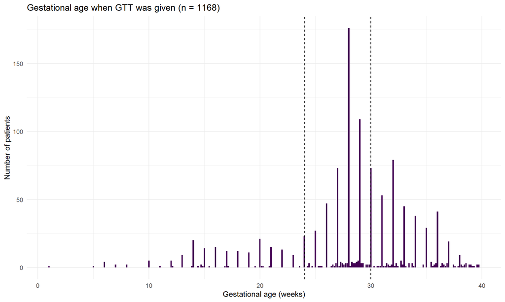

| **CUMH** | 475 (0.42) |
| --- | --- |
| **GP** | 573 (0.5) |
| **Private Rooms** | 72 (0.06) |
| **Other** | 16 (0.01) |

Note: 45 missing data for location of GTT.

**Figure 2** Distribution of gestational ages when the GTT was administered, by location.

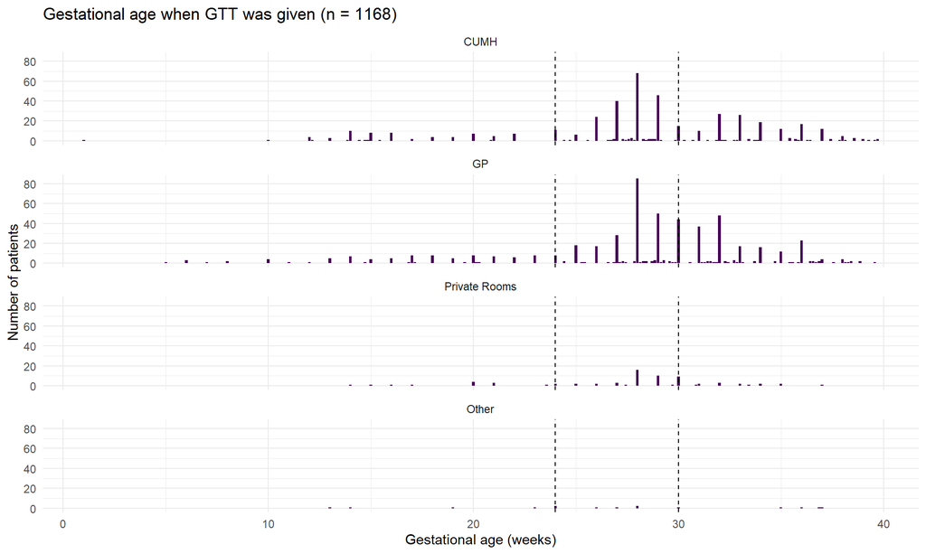

Fitting linear model: gtt_gstweeks ~ gtt_location

|  | Estimate | Std. Error | t value | Pr(>\|t\|) |
| --- | --- | --- | --- | --- |
| **(Intercept)** | 28.25 | 0.2791 | 101.2 | 0 |
| **gtt_locationGP** | -0.1127 | 0.3768 | -0.2992 | 0.7649 |
| **gtt_locationPrivate Rooms** | -0.6347 | 0.7651 | -0.8296 | 0.4069 |
| **gtt_locationOther** | -1.522 | 1.585 | -0.96 | 0.3373 |

|  | < 24 | 24 to 30 | 30+ |
| --- | --- | --- | --- |
| **CUMH** | 71 (0.15) | 222 (0.47) | 176 (0.38) |
| **GP** | 90 (0.16) | 236 (0.41) | 244 (0.43) |
| **Private Rooms** | 12 (0.17) | 37 (0.51) | 23 (0.32) |
| **Other** | 4 (0.27) | 6 (0.4) | 5 (0.33) |

Pearson’s Chi-squared test: `data$gtt_location` and `data$gdm_gest_cat` No association between the location of the GTT and the gestational week it was administered.

| Test statistic | df | P value |
| --- | --- | --- |
| 7.378 | 6 | 0.2873 |

## How is gestational weeks at GTT associated with predictors and screening factors?

### BMI

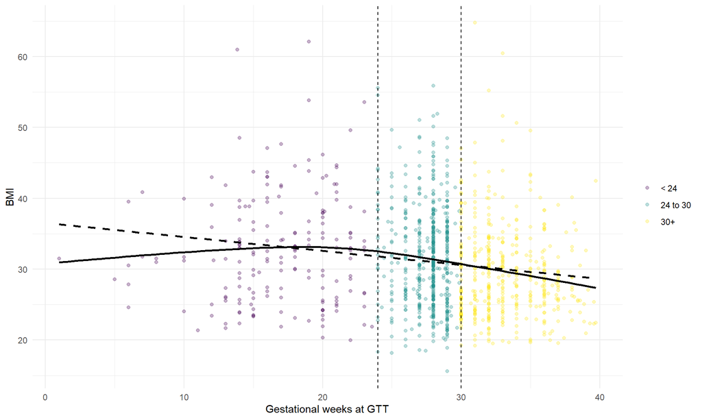

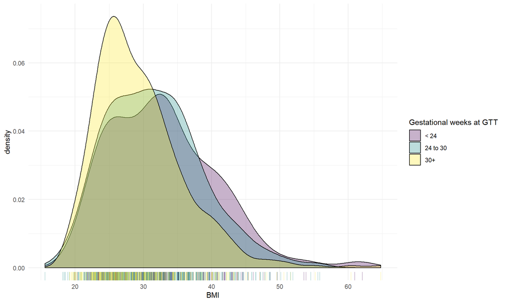

Fitting linear model: bmi ~ gtt_gstweeks

|  | Estimate | Std. Error | t value | Pr(>\|t\|) |
| --- | --- | --- | --- | --- |
| **(Intercept)** | 36.52 | 0.967 | 37.77 | 1.33e-203 |
| **gtt_gstweeks** | -0.197 | 0.03367 | -5.853 | 6.31e-09 |

Fitting linear model: bmi ~ gdm_gest_cat Conclusion: Larger women are picked up earlier.

|  | Estimate | Std. Error | t value | Pr(>\|t\|) |
| --- | --- | --- | --- | --- |
| **(Intercept)** | 32.88 | 0.5131 | 64.08 | 0 |
| **gdm_gest_cat24 to 30** | -1.226 | 0.5975 | -2.051 | 0.04047 |
| **gdm_gest_cat30+** | -3.394 | 0.6078 | -5.585 | 2.912e-08 |

### Age

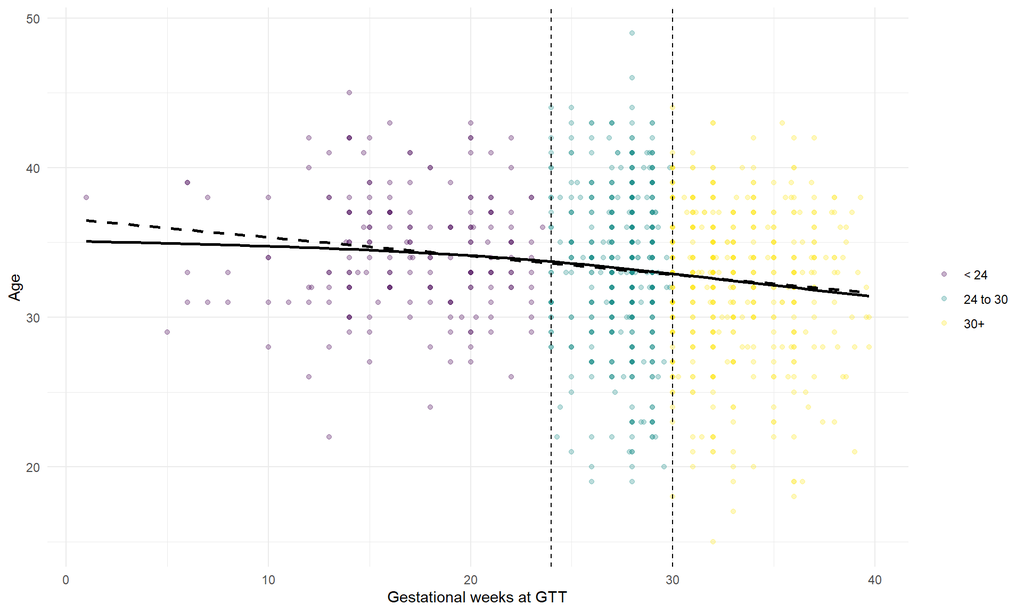

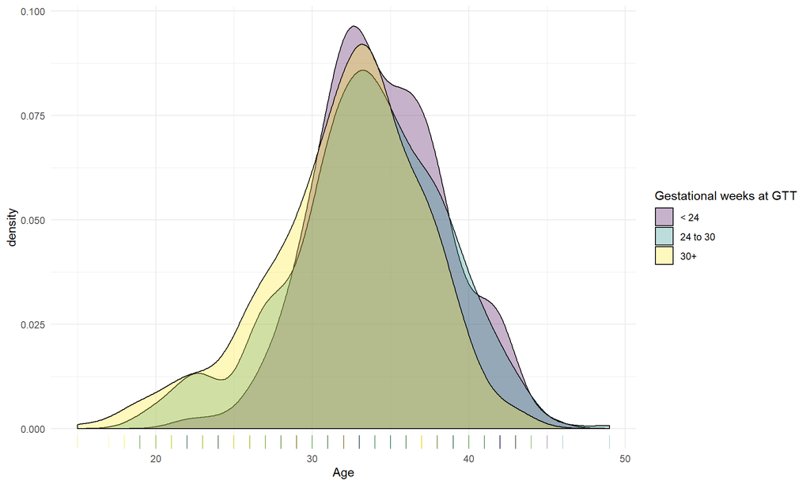

Fitting linear model: age ~ gtt_gstweeks

|  | Estimate | Std. Error | t value | Pr(>\|t\|) |
| --- | --- | --- | --- | --- |
| **(Intercept)** | 36.59 | 0.6715 | 54.49 | 7.411e-322 |
| **gtt_gstweeks** | -0.1243 | 0.02339 | -5.316 | 1.269e-07 |

Fitting linear model: age ~ gdm_gest_cat Conclusion: Older women are picked up earlier.

|  | Estimate | Std. Error | t value | Pr(>\|t\|) |
| --- | --- | --- | --- | --- |
| **(Intercept)** | 34.4 | 0.3556 | 96.74 | 0 |
| **gdm_gest_cat24 to 30** | -0.9212 | 0.4149 | -2.22 | 0.02661 |
| **gdm_gest_cat30+** | -2.241 | 0.4214 | -5.319 | 1.25e-07 |

### Previous GDM

|  | < 24 | 24 to 30 | 30+ |
| --- | --- | --- | --- |
| **0** | 58 (0.06) | 468 (0.5) | 418 (0.44) |
| **1** | 108 (0.56) | 41 (0.21) | 43 (0.22) |
| **2+** | 20 (0.65) | 9 (0.29) | 2 (0.06) |

Pearson’s Chi-squared test: `data$no_of_previous_gdm_episodes` and `data$gdm_gest_cat`

| Test statistic | df | P value |
| --- | --- | --- |
| 356.9 | 4 | 5.641e-76 * * * |

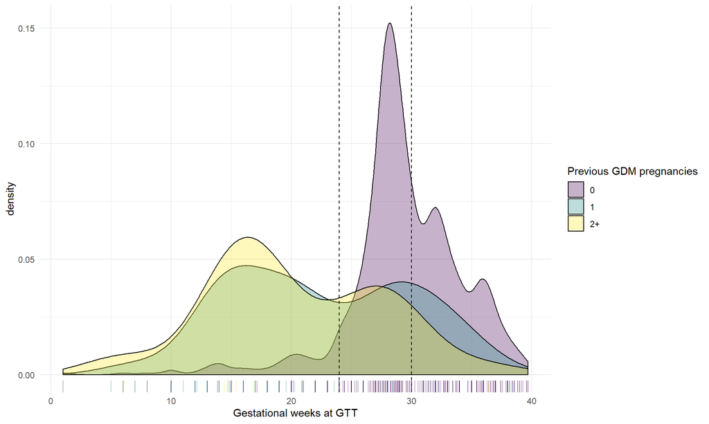

Fitting linear model: gtt_gstweeks ~ no_of_previous_gdm_episodes Conclusion: Previous GDM is a clear predictor of earlier GTT.

|  | Estimate | Std. Error | t value | Pr(>\|t\|) |
| --- | --- | --- | --- | --- |
| **(Intercept)** | 29.47 | 0.1745 | 168.9 | 0 |
| **no_of_previous_gdm_episodes1** | -7.038 | 0.4245 | -16.58 | 1.372e-55 |
| **no_of_previous_gdm_episodes2+** | -9.184 | 0.9787 | -9.384 | 3.225e-20 |

## Risky ethnicity

|  | < 24 | 24 to 30 | 30+ |
| --- | --- | --- | --- |
| **No** | 153 (0.16) | 415 (0.44) | 374 (0.4) |
| **Yes** | 21 (0.24) | 38 (0.44) | 27 (0.31) |

Pearson’s Chi-squared test: `data$risky_eth` and `data$gdm_gest_cat`

| Test statistic | df | P value |
| --- | --- | --- |
| 4.507 | 2 | 0.105 |

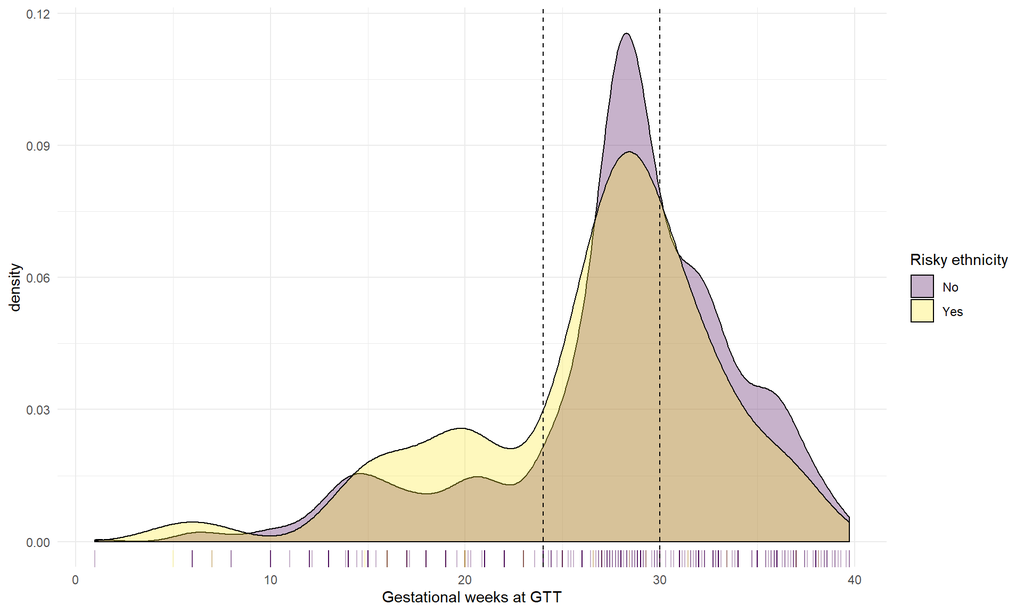

Fitting linear model: gtt_gstweeks ~ risky_eth Conclusion: A bit more early detection if yes.

|  | Estimate | Std. Error | t value | Pr(>\|t\|) |
| --- | --- | --- | --- | --- |
| **(Intercept)** | 28.02 | 0.2028 | 138.2 | 0 |
| **risky_ethYes** | -1.382 | 0.7013 | -1.971 | 0.04898 |

## Previous PCOS

|  | < 24 | 24 to 30 | 30+ |
| --- | --- | --- | --- |
| **No** | 167 (0.15) | 481 (0.45) | 431 (0.4) |
| **Yes** | 19 (0.21) | 37 (0.42) | 33 (0.37) |

Pearson’s Chi-squared test: `data$phx_pcos` and `data$gdm_gest_cat`

| Test statistic | df | P value |
| --- | --- | --- |
| 2.117 | 2 | 0.347 |

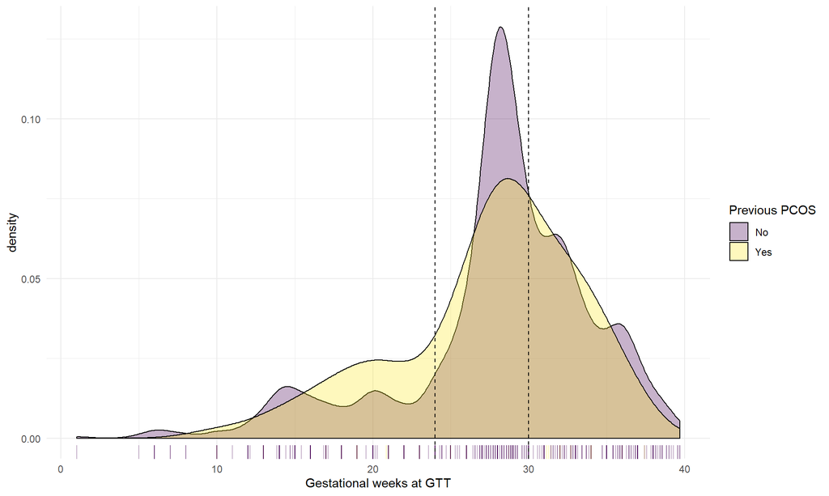

Fitting linear model: gtt_gstweeks ~ phx_pcos Conclusion: Maybe a very small effect. Noting to write home about.

|  | Estimate | Std. Error | t value | Pr(>\|t\|) |
| --- | --- | --- | --- | --- |
| **(Intercept)** | 28.13 | 0.1856 | 151.6 | 0 |
| **phx_pcosYes** | -0.6866 | 0.6722 | -1.021 | 0.3073 |

## Weght of biggest previous baby

weight_of_biggest_baby

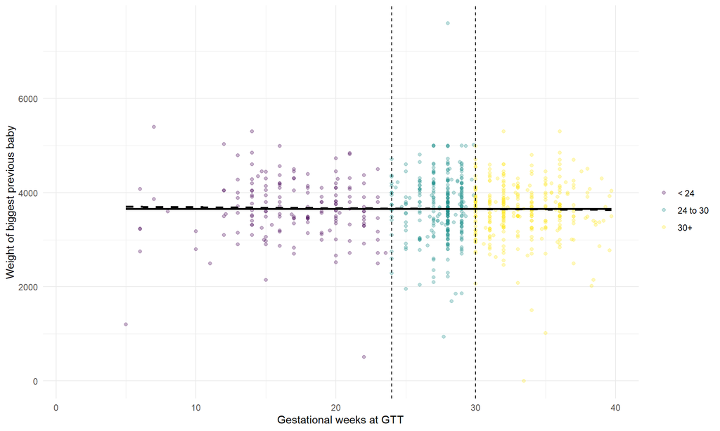

Conclusion: No relationship.

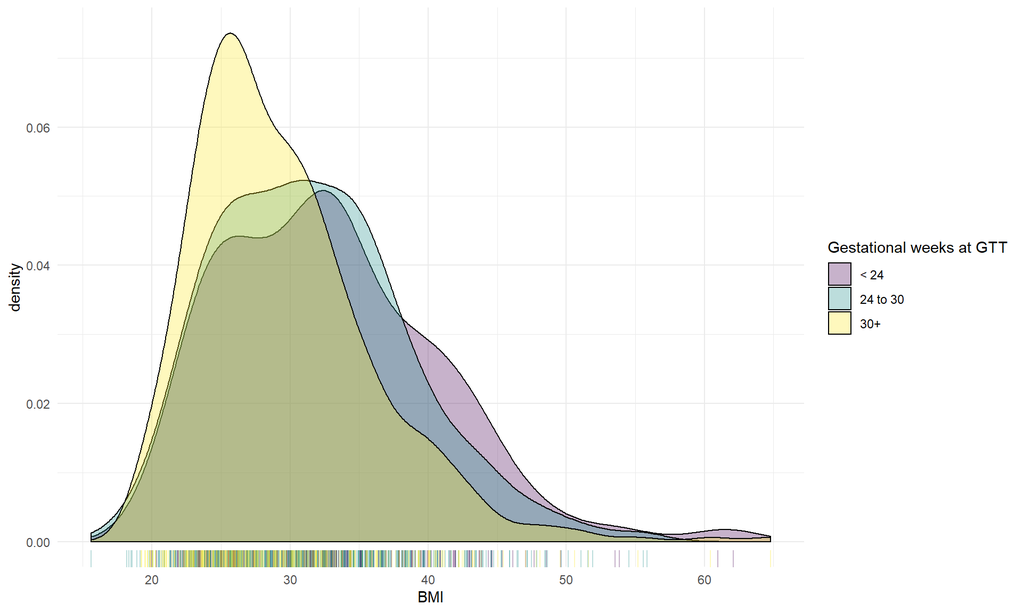

Fitting linear model: bmi ~ gtt_gstweeks

|  | Estimate | Std. Error | t value | Pr(>\|t\|) |
| --- | --- | --- | --- | --- |
| **(Intercept)** | 36.52 | 0.967 | 37.77 | 1.33e-203 |
| **gtt_gstweeks** | -0.197 | 0.03367 | -5.853 | 6.31e-09 |

Fitting linear model: bmi ~ gdm_gest_cat

|  | Estimate | Std. Error | t value | Pr(>\|t\|) |
| --- | --- | --- | --- | --- |
| **(Intercept)** | 32.88 | 0.5131 | 64.08 | 0 |
| **gdm_gest_cat24 to 30** | -1.226 | 0.5975 | -2.051 | 0.04047 |
| **gdm_gest_cat30+** | -3.394 | 0.6078 | -5.585 | 2.912e-08 |

Distribution of HBA1c

```
##    Min. 1st Qu.  Median    Mean 3rd Qu.    Max.    NA's
##    20.0    33.0    35.0    35.6    38.0    88.0      57
```

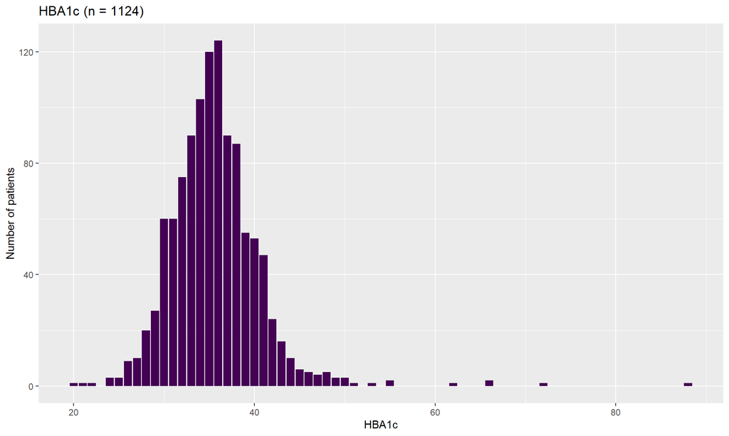

# Early vs late detection

<24 weeks vs > 30

Remove planned sections

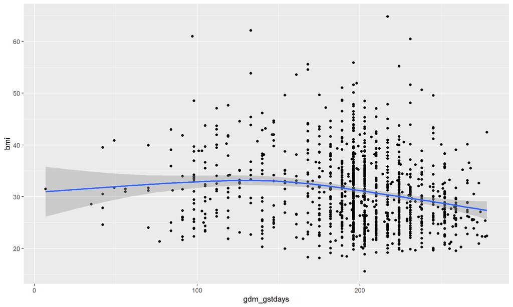

# Questions

If we could look at some to the following:

1. Ethnicity of group
2. Age of our mothers any change over 3 years
3. BMI- again any change over 3 years (where available for full group look at weight gain in pregnancy and any link with outcomes/infant size, delivery method, sub-group where body composition was available any link any associations)
4. Mean week gestation at diagnosis of GDM (any change with time)
5. Where were these women diagnosed, a link with place of diagnosis length of time to first consultation- very important as those dx with GP often missed and not seen for significant number of days- can we look at the group when GTT was performed by GP and outcomes- has this changed over the 3 years
6. Treatment modality- % diet/% metformin/% insulin and again changes over the years- how many seen by endocrinologist
7. Mean week of delivery (for whole group, any change over the years)
8. Delivery method/labour interventions whole group/any change over the years
9. Adverse maternal outcomes
10. Birth weight of infant/% LGA, % SGA
11. Admission to neo/length of stay (not available on full group)
12. Numbers breastfeeding on d/c- exclusive breast feeding/supplementary feeding
13. Number at high risk of Diabetes/abnormal OGGT, fasting glucose or HbA1c post partum- numbers who did not have OGGT done.

# Analysis

Overall, there were 1181 observations in the combinded data set (2016 n = 418; 2015 n = 369; 2014 n = 394)

## Outcomes

### Birth weight

Figure. Birth weight distribution by year

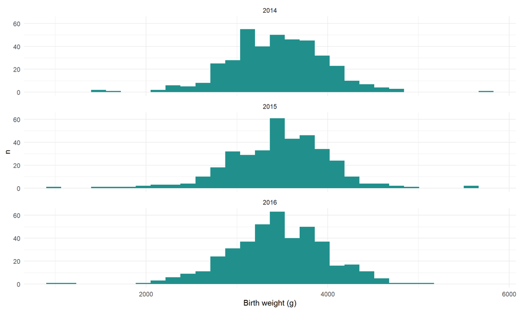

Fitting linear model: birth_weight_1 ~ factor(year)

|  | Estimate | Std. Error | t value | Pr(>\|t\|) |
| --- | --- | --- | --- | --- |
| **(Intercept)** | 3443 | 27.18 | 126.7 | 0 |
| **factor(year)2015** | 20.95 | 39.06 | 0.5362 | 0.5919 |
| **factor(year)2016** | 3.987 | 37.86 | 0.1053 | 0.9162 |

No substntial difference in the mean of BW across years.

### Macrosomic

The original in the dataset is a bit of a mess, so this was recreated from birth weight.

Table. Macrosomic in infant by year

|  | Macrosomic 4.5kg | No | Yes | NA |
| --- | --- | --- | --- | --- |
| Year |  |  |  |  |
| 2014 |  | 385 | 8 | 1 |
| 2015 |  | 360 | 9 | 0 |
| 2016 |  | 410 | 8 | 0 |

|  | Macrosomic 4 kg | No | Yes | NA |
| --- | --- | --- | --- | --- |
| Year |  |  |  |  |
| 2014 |  | 338 | 55 | 1 |
| 2015 |  | 317 | 52 | 0 |
| 2016 |  | 360 | 58 | 0 |

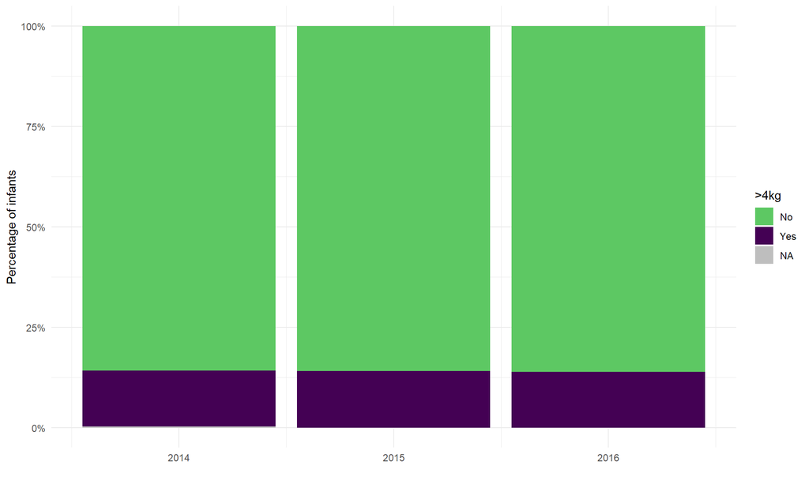

### Hypoglycaemia in infant

This really only had data for 2014 and that was spotty.

Table. Hypoglycaemia in infant by year

|  | Hypoglycaemia | Yes | No | NA |
| --- | --- | --- | --- | --- |
| Year |  |  |  |  |
| 2014 |  | 26 | 297 | 71 |
| 2015 |  | 4 | 15 | 350 |
| 2016 |  | 1 | 0 | 417 |

### Induction

|  | Induction | Yes | No | NA |
| --- | --- | --- | --- | --- |
| Year |  |  |  |  |
| 2014 |  | 195 | 165 | 34 |
| 2015 |  | 154 | 214 | 1 |
| 2016 |  | 179 | 239 | 0 |

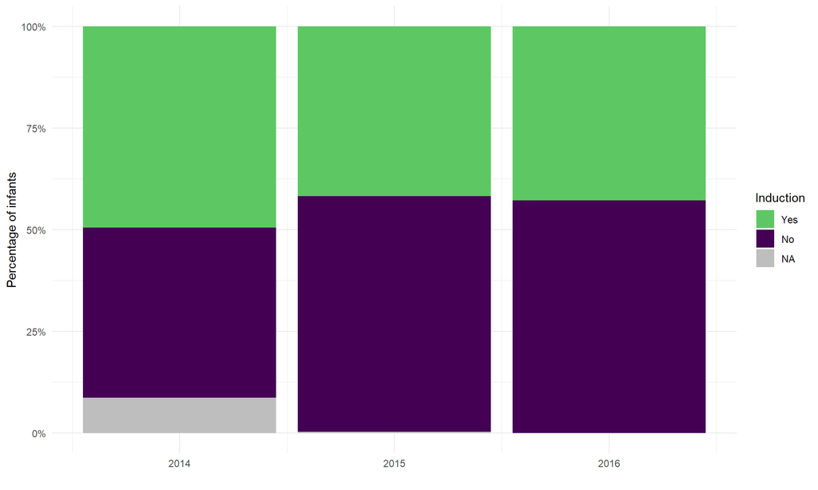

### Instrumental Delivery

|  | Instrumental Delivery | Nothing | Vacuum | Forceps | Combined | NA |
| --- | --- | --- | --- | --- | --- | --- |
| Year |  |  |  |  |  |  |
| 2014 |  | 323 | 41 | 22 | 2 | 6 |
| 2015 |  | 315 | 39 | 15 | 0 | 0 |
| 2016 |  | 351 | 59 | 8 | 0 | 0 |

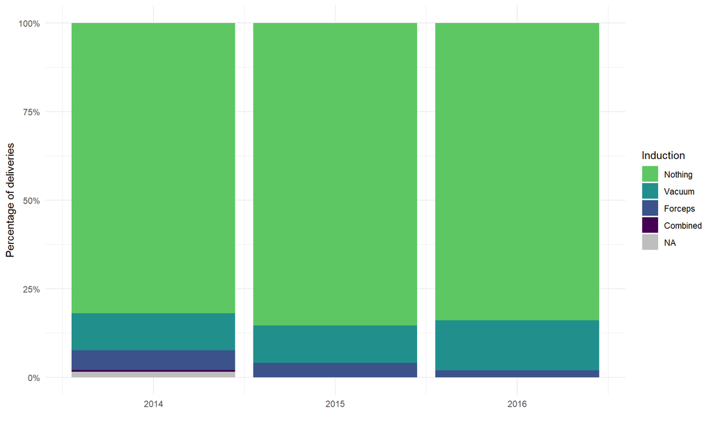

### Shoulder dystocia

|  | Shoulder dystocia | Yes | No | NA |
| --- | --- | --- | --- | --- |
| Year |  |  |  |  |
| 2014 |  | 3 | 390 | 1 |
| 2015 |  | 0 | 367 | 2 |
| 2016 |  | 2 | 416 | 0 |

# PPH

|  | PPH | Yes | No | NA |
| --- | --- | --- | --- | --- |
| Year |  |  |  |  |
| 2014 |  | 1 | 392 | 1 |
| 2015 |  | 5 | 363 | 1 |
| 2016 |  | 9 | 408 | 1 |

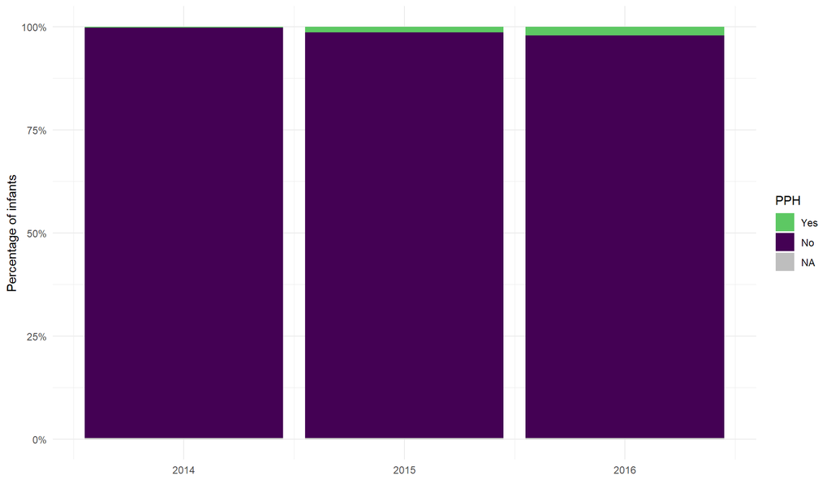

# Any maternal trauma

|  | Any maternal trauma | No | Yes | NA |
| --- | --- | --- | --- | --- |
| Year |  |  |  |  |
| 2014 |  | 218 | 174 | 2 |
| 2015 |  | 212 | 156 | 1 |
| 2016 |  | 239 | 179 | 0 |

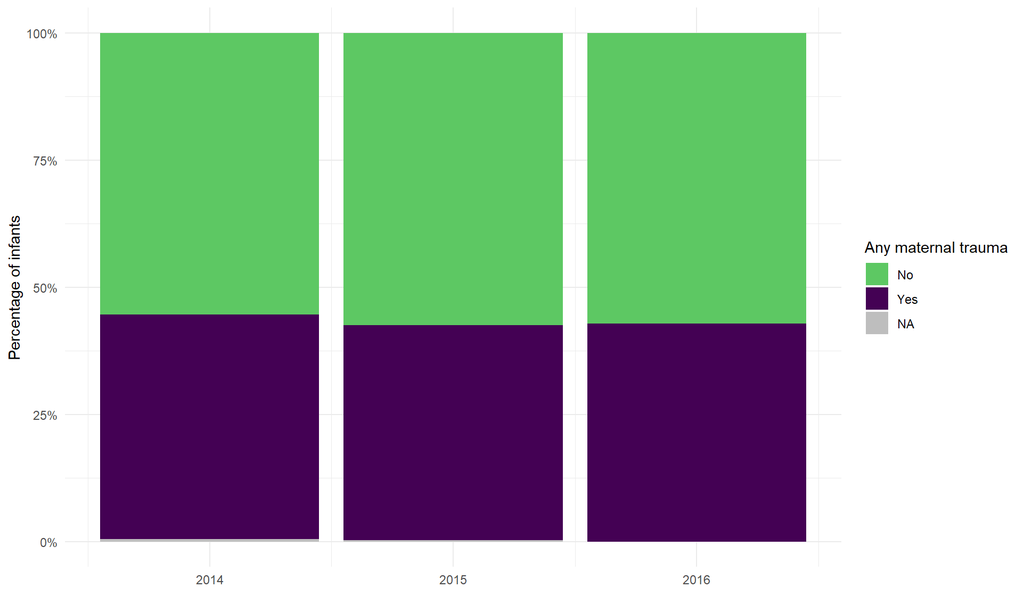

# NICU

|  | NICU | Yes | No | NA |
| --- | --- | --- | --- | --- |
| Year |  |  |  |  |
| 2014 |  | 66 | 327 | 1 |
| 2015 |  | 42 | 163 | 164 |
| 2016 |  | 52 | 359 | 7 |

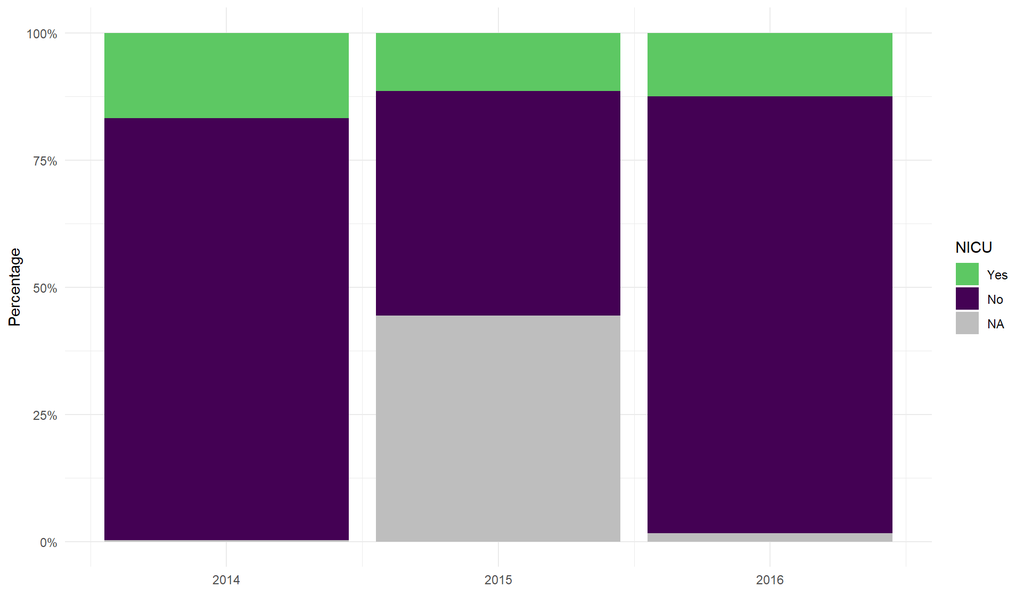